# Практична робота №5

## Тема: Закони розподілу та числові характеристики випадкових величин

## Мета: Набути практичних навичок у розв’язанні задач на знаходження законів розподілу та числових характеристик дискретних та неперервних випадкових величин, зокрема нормального закону, та розв’язання типових задач по цій темі.

## 1. Випадкові похибки вимірювань мають нормальний розподіл із СКВ 𝜎 = 20 мм та математичним сподіванням 𝜇 = 0. Знайти ймовірність того, що з трьох незалежних вимірювань похибка хоча б одного не перевищить за абсолютною величиною 4 мм.

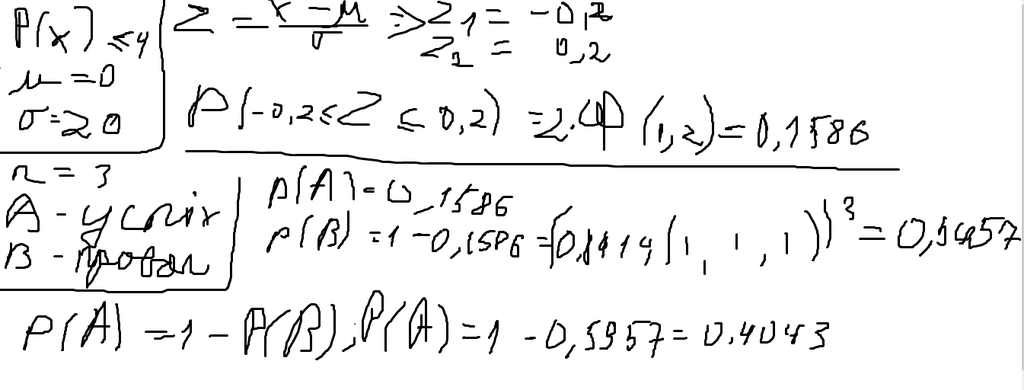

## 2. Автомат штампує деталі. Контролюється довжина деталі 𝑋, що має нормальний розподіл з математичним сподіванням 𝜇 = 50 мм (проектна довжина). Фактична довжина виготовлених деталей не менше 32 та не більше 68 мм.

## Знайти ймовірність того, що довжина наугад взятої деталі:

## а) більше 55 мм;

## б) менше 40 мм.

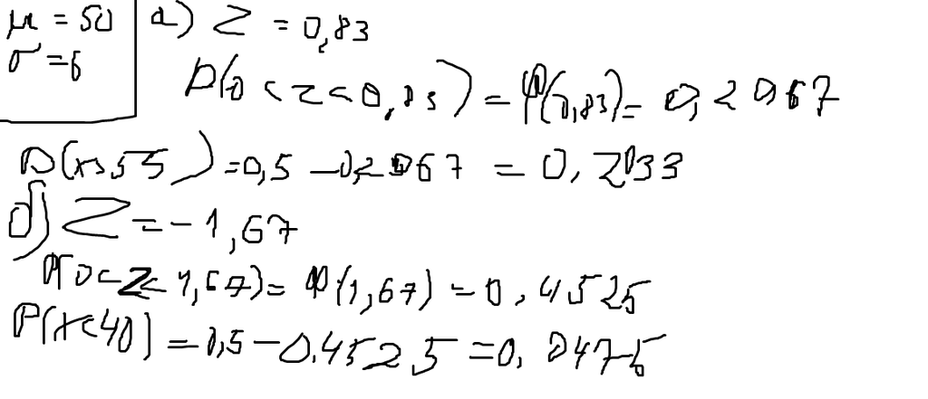

## 3. Відомо, що середня кількість пакетів, яку генерує один з терміналів локальної мережі підприємства протягом години має нормальний розподіл з параметрами (10; 2).

## Знайти:

## − ймовірність того, що за годину кількість пакетів відхилиться від середнього менше, ніж на 𝛿 = 0.01;

## − ймовірність того, що за годину кількість пакетів буде від 9 до 11;

## − ймовірність того, що за годину кількість пакетів буде < 9 або > 11.

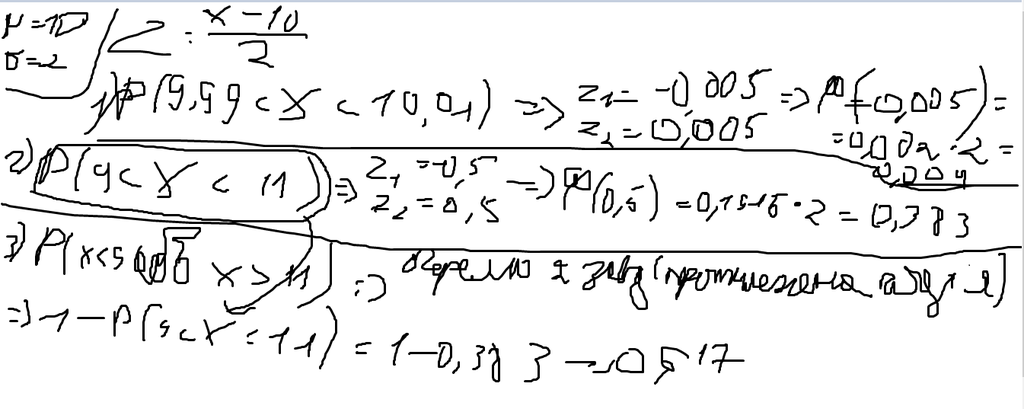

### 1. Закон розподілу: Ймовірності для 0, 1, 2, 3 та 4 влучень наступні: 0.0016 (0 влучень), 0.0256 (1 влучення), 0.1536 (2 влучення), 0.4096 (3 влучення), 0.4096 (4 влучення).

### 2. Ймовірності подій: Ймовірність того, що кількість влучень буде від 1 до 3 (включно), становить 0.5888 (або 58.88%). Ймовірність того, що кількість влучень буде більше 3 (тобто 4), становить 0.4096 (або 40.96%).

### 3. Числові характеристики: Математичне сподівання (середня кількість влучень): 3.2, Дисперсія: 0.64, Середнє квадратичне відхилення: 0.8

### 4. Форма розподілу: Асиметрія: -0.75 (розподіл має лівосторонню асиметрію, "хвіст" зліва). Ексцес: 0.0625 (розподіл є трохи гострішим за нормальний).

## 4. З ймовірністю влучення при одному пострілі 𝑝 = 0.7 стрілок стріляє у мішень до першого влучення, але може виконати не більше 4 пострілів. ДВВ 𝑋 –кількість промахів. Необхідно:

## 1) знайти закон розподілу ДВВ;

## 2) виразити функцію розподілу та функцію щільності розподілу ДВВ за допомогою функції Хевісайда та 𝛿 -функції Дірака;

## 3) побудувати графіки функцій розподілу та щільності розподілу;

## 4) знайти асиметрію та ексцес.

### 1. Закон розподілу: Х(промахи) - 0, 1, 2, 3, або 4: Р(х=0) = 0.7, Р(х=1) = 0.21, Р(х=2) = 0.063, Р(х=3) = 0.0189, Р(х=4) = 0.0081.

### 2. Середнє значення(математичне сподівання): 0,425 промахів

### 3. Форма розподілу: Асиметрія = 2.088(дуже сильна, правостороння). Ексцес = 4.664(дуже гострий в вершинах).

## 5. Двічі кинута гральна кістка. ДВВ 𝑋 – різниця між кількістю очок при першому киданні та кількістю очок при другому киданні. Необхідно:

## 1) знайти закон розподілу ДВВ;

## 2) побудувати графік функції щільності розподілу ДВВ;

## 3) знайти ймовірність події.

### 1. Закон розподілу: Ймовірність варіюється від 1/36 до 6/36 в залежності від значення Х.

### 2. Графік функції щільності розподілу: Графік симетричний, має вигляд трикутника - в найвищій точці(0) значення 6/36, в найнижчіх 5 і -5 - 1/36

### 3. Не зрозумів яку подію

## Контрольні питання

### 1. Pезультат кидків грального кубика, кількість студентів на лекції, кількість бракованих деталей.

### 2. Tемпература повітря , зріст , вага , час , об'єм.

### 3. Лише для скінченних.

### 4. Виправдати ми використання не можемо, але можемо визначити її обмеження і перейти до більш надійних методів аналізу.

### 5. Інтегральна функція розподілу.

### 6. Медіана, мода, дисперсія.

### 7. Ймовірнісний сенс полягає в тому що математичне сподівання це фіксоване теоретичне число, яке є фундаменательною характеристикою розподілу. Статистичний сенс полягає в тому що математичне сподівання це те конкретне число, до якого стабілізується середнє арифметичне ваших спостережень при великій кількості експериментів.

### 8. Ігноруючи асиметрію, можна неправильно визначити типовий результат розподілу, а ігноруючи ексцес, ви можете катастрофічно недооцінити реальні ризики.

### 9. Якщо для випадкової величини не існує математичного сподівання, то не існує і дисперсії, асиметрії та ексцесу, оскільки всі вони є характеристиками вищих порядків, які обчислюються на основі математичного сподівання.

### 10. Тому що за центральною граничною теоремою, стверджується, що сума великої кількості незалежних випадкових факторів прямує до нормального розподілу, навіть якщо самі фактори розподілені інакше. Оскільки багато реальних явищ, наприклад, похибки вимірювань, біологічні ознаки є результатом додавання багатьох таких малих впливів, їхній підсумковий розподіл часто виявляється близьким до нормального.

## Висновок

### На цьому практичному занятті ми набули практичних навичок у розв’язанні задач на знаходження законів розподілу та числових характеристик дискретних та неперервних випадкових величин, зокрема нормального закону, та розв’язання типових задач по цій темі.